# Worksheet 6: Text Analysis

Lucas Avelar

April 3, 2023

*This is the sixth in a series of worksheets for History 8510 at Clemson University. The goal of these worksheets is simple: practice, practice, practice. The worksheet introduces concepts and techniques and includes prompts for you to practice in this interactive document. When you are finished, you should change the author name (above), knit your document, and upload it to canvas. Don’t forget to commit your changes as you go and push to github when you finish the worksheet.*

Text analysis is an umbrella for a number of different methodologies. Generally speaking, it involves taking a set (or corpus) of textual sources, turning them into data that a computer can understand, and then running calculations and algorithms using that data. Typically, at its most basic level, that involves the counting of words.

**Text analysis can be broken down into 4 general steps:**

1. Acquiring a corpus
2. Preparing the text or Pre-processing
3. Choosing an analytical tool * (There are many different tools or methods for text analysis. Take a minute and Google each of these methodologies: tf-idf, topic modeling, sentiment analysis, word vector analysis, n-grams)
4. Analyzing the results

In this worksheet we are focusing on basic text analysis. We’ll learn how to load textual data into R, how to prepare it, and then how to analyze it using tf-idf or term-frequency according to inverse document frequency.

Before doing too much, lets load a few relevant libraries. The last few you will likely need to install.

```r
library(tidyverse)
library(tidytext)
library(readtext)
library(widyr)
library(SnowballC)
```

## Acquiring a Corpus

First, lets install the State of the Union package. This package contains text of all the state of the Union addresses from Washington to Trump. Run `install.packages` to install the `sotu` package.

```r
library(sotu)
```

This package includes both the metadata about these speeches in `sotu_meta` and the texts themselves in `sotu_texts`. Lets first look at the metadata associated with this package.

```r
meta <- as.data.frame(sotu_meta)
head(meta)
```

```
##   X         president year years_active       party sotu_type
## 1 1 George Washington 1790    1789-1793 Nonpartisan    speech
## 2 2 George Washington 1790    1789-1793 Nonpartisan    speech
## 3 3 George Washington 1791    1789-1793 Nonpartisan    speech
## 4 4 George Washington 1792    1789-1793 Nonpartisan    speech
## 5 5 George Washington 1793    1793-1797 Nonpartisan    speech
## 6 6 George Washington 1794    1793-1797 Nonpartisan    speech
```

This package also includes a function that will let us write all of the files to disk. This is crucial but also an unusual step because when conducting text analysis in the real world, you will not have an R package filled with the data. Rather you will have to organize the metadata and load the files yourself. Writing these to the disk allows us to practice that step.

```r
file_paths <- sotu_dir(dir = "sotu_files")
head(file_paths)
```

```
## [1] "sotu_files/george-washington-1790a.txt"
## [2] "sotu_files/george-washington-1790b.txt"
## [3] "sotu_files/george-washington-1791.txt"
## [4] "sotu_files/george-washington-1792.txt"
## [5] "sotu_files/george-washington-1793.txt"
## [6] "sotu_files/george-washington-1794.txt"
```

What this does is create a new directory (sotu_files) and adds each State of the Union address as a text file. Notice each speech is its own .txt file that is comprised of just the text of the speech.

1. Take a look at the directory in your files pane and open one of the documents.

Now lets load all these texts into R using the `readtext()` function. First look up the documentation for this function and read about it.

```r
sotu_texts <- readtext(file_paths)
```

Take a look at sotu_texts now. Notice that we have two columns, one filled with the text, and one with a document id.

```r
head(sotu_texts, n = 5)
```

```
## readtext object consisting of 5 documents and 0 docvars.
## # Description: df [5 × 2]
##   doc_id                   text
##   <chr>                    <chr>
## 1 abraham-lincoln-1861.txt "\"\n\n Fellow-\"..."
## 2 abraham-lincoln-1862.txt "\"\n\n Fellow-\"..."
## 3 abraham-lincoln-1863.txt "\"\n\n Fellow-\"..."
## 4 abraham-lincoln-1864.txt "\"\n\n Fellow-\"..."
## 5 andrew-jackson-1829.txt  "\"\n\n Fellow \"..."
```

Now our textual data is loaded into R but the textual data and the metadata are in two different data frames. Lets combine them. Note that this isn’t the way I would typically recommend doing this but its a quirk of the SOTU data. Typically when I create a metadata spreadsheet for a textual dataset I have a column for the file name which makes joining the textual data and metadata together easier. Here, we’ll need to sort the dataset so that is alphabetical and then join the two together.

```r
sotu_whole <-
  sotu_meta %>%
  arrange(president) %>% # sort metadata
  bind_cols(sotu_texts) %>% # combine with texts
  as_tibble() # convert to tibble for better screen viewing
glimpse(sotu_whole)
```

```
## Rows: 240
## Columns: 8
## $ X            <int> 73, 74, 75, 76, 41, 42, 43, 44, 45, 46, 47, 48, 77, 78, 7…
## $ president    <chr> "Abraham Lincoln", "Abraham Lincoln", "Abraham Lincoln", …
## $ year         <int> 1861, 1862, 1863, 1864, 1829, 1830, 1831, 1832, 1833, 183…
## $ years_active <chr> "1861-1865", "1861-1865", "1861-1865", "1861-1865", "1829…
## $ party        <chr> "Republican", "Republican", "Republican", "Republican", "…
## $ sotu_type    <chr> "written", "written", "written", "written", "written", "w…
## $ doc_id       <chr> "abraham-lincoln-1861.txt", "abraham-lincoln-1862.txt", "…
## $ text         <chr> "\n\n Fellow-Citizens of the Senate and House of Represen…
```

Now our data is loaded into R and its ready to be pre-processed.

## Pre-Processing

### Tokenizing

One of the most basic pre-processing techniques for textual data is to tokenize it. Tokenization is essentially splitting a phrase, sentence, paragraph, or an entire text document into smaller units, such as individual words or terms. Each of these smaller units are called tokens. The tokens could be words, numbers or punctuation marks but, for historians, its common to remove the numbers and punctuation too. To do this we’ll create a data frame where each row contains a single word with its metadata as unit of observation.

`tidytext` provides a function called `unnest_tokens().` We can use this to convert our sotu_whole data frame into one that is tokenized. It takes three arguments:

```
* a tibble or data frame which contains the text
* the name of the newly created column that will contain the tokens
* the name of the column within the data frame which contains the text to be tokenized
```

```r
tidy_sotu <- sotu_whole %>%
  unnest_tokens(word, text)
tidy_sotu
```

```
## # A tibble: 1,988,203 × 8
##        X president        year years_active party      sotu_type doc_id    word
##    <int> <chr>           <int> <chr>        <chr>      <chr>     <chr>     <chr>
##  1    73 Abraham Lincoln  1861 1861-1865    Republican written   abraham-… fell…
##  2    73 Abraham Lincoln  1861 1861-1865    Republican written   abraham-… citi…
##  3    73 Abraham Lincoln  1861 1861-1865    Republican written   abraham-… of
##  4    73 Abraham Lincoln  1861 1861-1865    Republican written   abraham-… the
##  5    73 Abraham Lincoln  1861 1861-1865    Republican written   abraham-… sena…
##  6    73 Abraham Lincoln  1861 1861-1865    Republican written   abraham-… and
##  7    73 Abraham Lincoln  1861 1861-1865    Republican written   abraham-… house
##  8    73 Abraham Lincoln  1861 1861-1865    Republican written   abraham-… of
##  9    73 Abraham Lincoln  1861 1861-1865    Republican written   abraham-… repr…
## 10    73 Abraham Lincoln  1861 1861-1865    Republican written   abraham-… in
## # … with 1,988,193 more rows
```

`unnest_tokens()` also did something else that is really important: it made everything lowercase and took out all punctuation. The function contains options if we wanted to keep those elements, but for our purposes we don’t.

The function `unnest_tokens()` also has an option called token. Tokenizing by word is the default but you could also tokenize by characters, ngrams, lines, or sentences.

(@)Use the documentation to tokenize the dataset into sentences:

```r
sent_sotu <- sotu_whole %>%
  unnest_tokens(sentence, text, token = "sentences")
sent_sotu
```

```
## # A tibble: 70,761 × 8
##        X president        year years_active party      sotu_type doc_id  sente…¹
##    <int> <chr>           <int> <chr>        <chr>      <chr>     <chr>   <chr>
##  1    73 Abraham Lincoln  1861 1861-1865    Republican written   abraha… fellow…
##  2    73 Abraham Lincoln  1861 1861-1865    Republican written   abraha… you wi…
##  3    73 Abraham Lincoln  1861 1861-1865    Republican written   abraha… a disl…
##  4    73 Abraham Lincoln  1861 1861-1865    Republican written   abraha… a nati…
##  5    73 Abraham Lincoln  1861 1861-1865    Republican written   abraha… nation…
##  6    73 Abraham Lincoln  1861 1861-1865    Republican written   abraha… the di…
##  7    73 Abraham Lincoln  1861 1861-1865    Republican written   abraha… if it …
##  8    73 Abraham Lincoln  1861 1861-1865    Republican written   abraha… if we …
##  9    73 Abraham Lincoln  1861 1861-1865    Republican written   abraha… the pr…
## 10    73 Abraham Lincoln  1861 1861-1865    Republican written   abraha… those …
## # … with 70,751 more rows, and abbreviated variable name ¹sentence
```

We’ve talked about n-grams loosely in class. But lets define it more formally. An n-gram is a contiguous sequence of n items from a given sample of text or speech. The n stands for the number of items. So for example, a bi-gram is sets of two words.

For example, if I had the string: “Nothing to fear but fear itself” A bi-gram would look like this: Nothing to, to fear, fear but, but fear, fear itself.

A tri-gram would look like this: Nothing to fear, to fear but, but fear itself

We can use unnest_tokens() to create n-grams for us. To do that we just have to add an extra option that defines n.

```r
sotu_bigrams <- sotu_whole %>%
  unnest_tokens(bigram, text, token = "ngrams", n = 2)
head(sotu_bigrams$bigram)
```

```
## [1] "fellow citizens" "citizens of"     "of the"          "the senate"
## [5] "senate and"      "and house"
```

2. Use `unest_tokens()` to create tri-grams.

```r
sotu_trigrams <- sotu_whole %>%
  unnest_tokens(trigram, text, token = "ngrams", n = 3)
head(sotu_trigrams$trigram)
```

```
## [1] "fellow citizens of" "citizens of the"    "of the senate"
## [4] "the senate and"     "senate and house"   "and house of"
```

### Stopwords

Another crucial component of text analysis is removing stopwords. Stopwords are words like “I, he, she, of, the” that are common and don’t convey meaning. Because they are highly common they don’t tell us anything about the content of the text itself.

There are stopwords that come with the `tidytext` package.

```r
stop_words
```

```
## # A tibble: 1,149 × 2
##    word        lexicon
##    <chr>       <chr>
##  1 a           SMART
##  2 a's         SMART
##  3 able        SMART
##  4 about       SMART
##  5 above       SMART
##  6 according   SMART
##  7 accordingly SMART
##  8 across      SMART
##  9 actually    SMART
## 10 after       SMART
## # … with 1,139 more rows
```

This is just one example of stopwords. You can find other lists such as stopwords in other languages or [stopwords designed specifically for the 19th century.](https://www.matthewjockers.net/macroanalysisbook/expanded-stopwords-list/) Its also possible you may want to edit the list of stopwords to include some of your own. For example, if we wanted to add the word, “America” to the stopwords list we could use add_row to do so:

```r
stop_words_custom <- stop_words %>% add_row(word="America", lexicon="NA")
```

For now lets just remove the default stopwords. The easiest way to do that here is to do an anti-join. We join and return all rows from our table of tokens tidy_sotu where there are no matching values in our list of stopwords.

```r
tidy_sotu_words <- tidy_sotu %>%
  anti_join(stop_words)
tidy_sotu_words
```

```
## # A tibble: 787,851 × 8
##        X president        year years_active party      sotu_type doc_id    word
##    <int> <chr>           <int> <chr>        <chr>      <chr>     <chr>     <chr>
##  1    73 Abraham Lincoln  1861 1861-1865    Republican written   abraham-… fell…
##  2    73 Abraham Lincoln  1861 1861-1865    Republican written   abraham-… citi…
##  3    73 Abraham Lincoln  1861 1861-1865    Republican written   abraham-… sena…
##  4    73 Abraham Lincoln  1861 1861-1865    Republican written   abraham-… house
##  5    73 Abraham Lincoln  1861 1861-1865    Republican written   abraham-… repr…
##  6    73 Abraham Lincoln  1861 1861-1865    Republican written   abraham-… midst
##  7    73 Abraham Lincoln  1861 1861-1865    Republican written   abraham-… unpr…
##  8    73 Abraham Lincoln  1861 1861-1865    Republican written   abraham-… poli…
##  9    73 Abraham Lincoln  1861 1861-1865    Republican written   abraham-… trou…
## 10    73 Abraham Lincoln  1861 1861-1865    Republican written   abraham-… grat…
## # … with 787,841 more rows
```

```r
#another way to do this would be to filter by words NOT in the stop word list like this:  filter(!word %in% stop_words$word)
```

### Stemming

The third common kind of pre-process is called word stemming. This process reduces a word to its root stem. So for example: fishing becomes fish, fished becomes fish, fishes becomes fish. You can easily see how this might be useful for capturing all forms of a word.

`tidytext` doesn’t have its own word stemming function. Instead we have to rely on the functions provided by `hunspell` or `SnowballC`. I prefer `SnowballC`. You may need to install it before running the below code.

```r
library(SnowballC)
tidy_sotu_words %>%
        mutate(word_stem = wordStem(word))
```

```
## # A tibble: 787,851 × 9
##        X president        year years_active party   sotu_…¹ doc_id word  word_…²
##    <int> <chr>           <int> <chr>        <chr>   <chr>   <chr>  <chr> <chr>
##  1    73 Abraham Lincoln  1861 1861-1865    Republ… written abrah… fell… fellow
##  2    73 Abraham Lincoln  1861 1861-1865    Republ… written abrah… citi… citizen
##  3    73 Abraham Lincoln  1861 1861-1865    Republ… written abrah… sena… senat
##  4    73 Abraham Lincoln  1861 1861-1865    Republ… written abrah… house hous
##  5    73 Abraham Lincoln  1861 1861-1865    Republ… written abrah… repr… repres
##  6    73 Abraham Lincoln  1861 1861-1865    Republ… written abrah… midst midst
##  7    73 Abraham Lincoln  1861 1861-1865    Republ… written abrah… unpr… unprec…
##  8    73 Abraham Lincoln  1861 1861-1865    Republ… written abrah… poli… polit
##  9    73 Abraham Lincoln  1861 1861-1865    Republ… written abrah… trou… troubl
## 10    73 Abraham Lincoln  1861 1861-1865    Republ… written abrah… grat… gratit…
## # … with 787,841 more rows, and abbreviated variable names ¹sotu_type,
## #   ²word_stem
```

Now if you compare the word and word_stem columns you can see the effect that wordStem had. Notice that it works well in cases like

citizens = citizen

But it does some odd things to words like representatives. Whether this is useful for you will depend on the question your asking (and the OCR accuracy) but its a useful technique to be familiar with nevertheless.

## Analysis

Lets reset our work space and ensure that our df is loaded with single tokenized words and filter by our stopword list. Go ahead and clear your environment using the broom button and then run the below code. This code is simply everything we’ve run up to this point.

```r
meta <- as.data.frame(sotu_meta)
file_paths <- sotu_dir(dir = "sotu_files")
sotu_texts <- readtext(file_paths)
sotu_whole <-
  sotu_meta %>%
  arrange(president) %>% # sort metadata
  bind_cols(sotu_texts) %>% # combine with texts
  as_tibble()
tidy_sotu <- sotu_whole %>%
  unnest_tokens(word, text) %>%
  anti_join(stop_words)
```

3. Before we move forward, take a minute a describe the chunk of code you just ran. What does each section do and how does it reflect the workflow for a topic modeling project? What are the important steps that are unique to topic modeling?

> meta <- as.data.frame(sotu_meta) #here, we retrieve metadata for the State of the Union Addresses and store it as a dataframe. file_paths <- sotu_dir(dir = “sotu_files”) sotu_texts <- readtext(file_paths) sotu_whole <- sotu_meta %>%  
> arrange(president) %>% # sort metadata bind_cols(sotu_texts) %>% # combine with texts as_tibble() #here, we combine metadata and data to form the corpus object to be preprocessed and analyzed. tidy_sotu <- sotu_whole %>% unnest_tokens(word, text) %>% anti_join(stop_words) #here, we preprocess the corpus and turn it into tidy text data through tokenization.

> These steps are the first part of a workflow for a topic modeling that takes the tidy text data after preprocessing and unveils the abstract themes in the corpus, separating words into topics.

The most basic kind of analysis we might be interested in doing is counting words. We can do that easily using the `count()` function:

```r
tidy_sotu %>%
  count(word, sort = TRUE)
```

```
## # A tibble: 29,897 × 2
##    word           n
##    <chr>      <int>
##  1 government  7597
##  2 congress    5808
##  3 united      5156
##  4 people      4298
##  5 country     3641
##  6 public      3419
##  7 time        3188
##  8 american    2988
##  9 war         2976
## 10 world       2633
## # … with 29,887 more rows
```

Now we know that the most used word in state of the union speeches is government. But what if we wanted to look at when presidents use the words war versus the word peace?

```r
tidy_sotu %>%
  filter(word %in% c("war", "peace")) %>%
  count(year, word)
```

```
## # A tibble: 442 × 3
##     year word      n
##    <int> <chr> <int>
##  1  1790 peace     3
##  2  1790 war       4
##  3  1791 peace     4
##  4  1791 war       1
##  5  1792 peace     5
##  6  1792 war       2
##  7  1793 peace     6
##  8  1793 war       4
##  9  1794 peace     3
## 10  1794 war       1
## # … with 432 more rows
```

This data frame is to big to understand quickly without visualizing it. We can create a bar chart to better understand it:

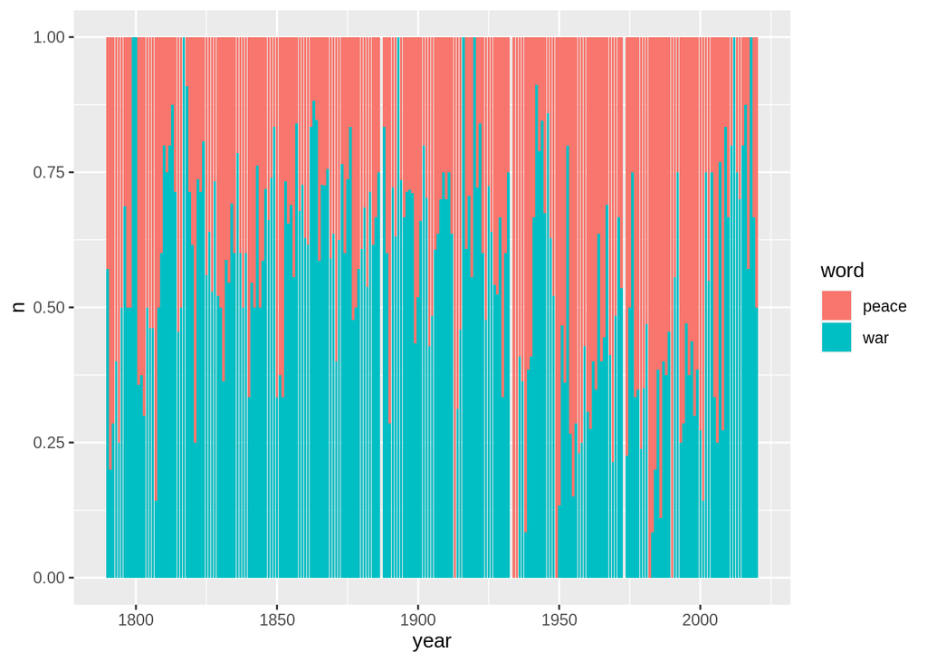

```r
library(ggplot2)
tidy_sotu %>%
  filter(word %in% c("war", "peace")) %>%
  count(year, word) %>%
  ggplot(aes(year, n, fill = word)) +
    geom_col(position = "fill")
```

We also might want to ask about the average length of each president’s state of the union address. Who had the longest speech and who had the shortest?

```r
test3 <- tidy_sotu %>%
  count(president, doc_id) %>%
  group_by(doc_id) %>%
  summarize(avg_words = mean(n)) %>%
  arrange(desc(avg_words))
```

```r
test <- tidy_sotu %>%
  select(president, sotu_type, doc_id) %>%
  group_by(president, doc_id) %>%
  summarize(count = n()) %>%
  arrange(desc(count))
```

> Jimmy Carter made the longest address while Dwight D. Eisenhower made the shortest.
4. Think back to the metadata that we loaded about these speeches. Why are more modern president’s state of the union addresses shorter

```r
test2 <- tidy_sotu %>%
  select(sotu_type, doc_id) %>%
  group_by(sotu_type, doc_id) %>%
  summarize(average = mean(n)) %>%
  arrange(desc(average))
```

> Johm Adams’ short SOTUS was a spoken speech while William Taft’s long SOTUS was a written speech.
5. Filter the dataset to address this discrepancy and the recreate these statistics:

```r
vis.avg.word <- tidy_sotu %>%
  group_by(sotu_type, president, doc_id) %>%
  count(doc_id) %>%
  group_by(sotu_type, president) %>%
  summarize(average = mean(n)) %>%
  arrange(desc(average))
```

```r
plot <- ggplot(vis.avg.word, mapping = aes(x = president, y = average, fill = sotu_type)) +
  geom_bar(position = "dodge", stat = "identity") + coord_flip()
ggsave(plot, filename="myfigure.png")
```

### Term Frequency

Often, the raw frequency of a term is not as useful as relative frequency. In other words, how often that word appears relative to the total number of words in a text. This ratio is called **term frequency**.

You can calculate the term frequency by dividing the total occurrences of a word by the total number of words. Typically you want to do this per document.

Here’s an easy way to calculate it:

```r
tidy_sotu_rel.freq <- tidy_sotu %>%
  count(doc_id, word, sort = T)  %>%# count occurrence of word and sort descending
  group_by(doc_id) %>%
  mutate(n_tot = sum(n), # count total number of words per doc
         term_freq = n/n_tot)
```

We can assume that words with a high frequency in the text are more important or significant. Here we can find the words with the most significance for each president:

```r
tidy_sotu %>%
  count(president, word) %>%  # count n for each word
  group_by(president) %>%
  mutate(n_tot = sum(n), # count total number of words per doc
         term_freq = n/n_tot) %>%
  arrange(desc(term_freq)) %>% # sort by term frequency
  top_n(1) %>%  # take the top for each president
  print(n = Inf) # print all rows
```

```
## # A tibble: 44 × 5
## # Groups:   president [42]
##    president             word           n n_tot term_freq
##    <chr>                 <chr>      <int> <int>     <dbl>
##  1 John Adams            united        49  2768   0.0177
##  2 John Tyler            government   209 12596   0.0166
##  3 Martin Van Buren      government   256 17145   0.0149
##  4 William J. Clinton    people       336 22713   0.0148
##  5 Franklin D. Roosevelt war          283 19311   0.0147
##  6 William McKinley      government   452 31188   0.0145
##  7 Andrew Jackson        government   436 31031   0.0141
##  8 Donald Trump          american     135  9690   0.0139
##  9 Andrew Johnson        government   207 14968   0.0138
## 10 George Washington     united        86  6226   0.0138
## 11 Calvin Coolidge       government   274 20518   0.0134
```

[output cut: 33 more lines]

6. The code above is commented to help you follow it. Walk through the code above, and explain what each line does in your own words. If its a function you are unfamiliar with, look up the documentation. > First, count() counts the amount of times each word is used by each president. Then, the code groups the result by president and uses mutate() to create a new column in the dataframe called “n_tot” containing the number of words in total in each document, per president. it also creates another colum called “term_freq” that containes the term frequency for each word. Then, it sorts out by the highest term frequency and it uses the funciton top_n() with n = 1, which retrieves the first observation in the dataframe for each president.

### TF-IDF

The above measures the frequency of terms within individual documents. But what if we know about words that seem more important based on the contents of the **entire** corpus? That is where tf-idf or term-frequency according to inverse document frequency comes in.

Tf-idf measures how important a word is within a corpus by scaling term frequency per document according to the inverse of the term’s document frequency (number of documents within the corpus in which the term appears divided by the number of documents). The tf–idf value increases proportionally to the number of times a word appears in the document and is offset by the number of documents in the corpus that contain the word, which helps to adjust for the fact that some words appear more frequently in general.

Don’t worry too much about how tf-idf is calculated. But if you feel like you are a bit lost and want to understand the specifics - I recommend reading the [tf-idf wikipedia page](https://en.wikipedia.org/wiki/Tf%E2%80%93idf) and this blog post from [*Learn Data Science*](https://www.learndatasci.com/glossary/tf-idf-term-frequency-inverse-document-frequency/).

We’ll calculate tf-idf in the next code chunk but lets talk for a second about what that number will represent. It will be:

```
* lower for words that appear frequently in many documents of the corpus, and lowest when the word occurs in virtually all documents.
* higher for words that appear frequently in just a few documents of the corpus,this lending high discriminatory power to those few documents.
```

Luckily, `tidytext` provides a function for calculating tf-idf. To calculate tf-idf the function needs a list of every word in every document and the count. Like this:

```r
word.count <- tidy_sotu %>%
  count(doc_id, word, sort = TRUE)
```

We can feed that to the function and get the tf-idf:

```r
sotu.tf.idf <- tidy_sotu %>%
  count(doc_id, word, sort = TRUE)  %>%
  bind_tf_idf(word, doc_id, n)
head(sotu.tf.idf)
```

```
## # A tibble: 6 × 6
##   doc_id                       word           n     tf     idf    tf_idf
##   <chr>                        <chr>      <int>  <dbl>   <dbl>     <dbl>
## 1 harry-s-truman-1946.txt      dollars      207 0.0164 0.598   0.00981
## 2 jimmy-carter-1980b.txt       congress     204 0.0126 0.00418 0.0000528
## 3 harry-s-truman-1946.txt      war          201 0.0159 0.0339  0.000540
## 4 william-howard-taft-1910.txt government   164 0.0147 0.00418 0.0000613
## 5 james-k-polk-1846.txt        mexico       158 0.0225 0.799   0.0180
## 6 richard-m-nixon-1974b.txt    federal      141 0.0141 0.293   0.00414
```

Lets look at what the words with the highest tf-idf score are.

```r
sotu.tf.idf %>% arrange(desc(tf_idf))
```

```
## # A tibble: 358,186 × 6
##    doc_id                        word          n      tf   idf tf_idf
##    <chr>                         <chr>     <int>   <dbl> <dbl>  <dbl>
##  1 donald-trump-2019.txt         applause    104 0.0424   2.22 0.0942
##  2 lyndon-b-johnson-1966.txt     vietnam      32 0.0152   2.35 0.0356
##  3 jimmy-carter-1980a.txt        soviet       31 0.0218   1.49 0.0325
##  4 george-w-bush-2003.txt        hussein      19 0.00811  3.87 0.0314
##  5 george-w-bush-2003.txt        saddam       19 0.00811  3.69 0.0299
##  6 franklin-d-roosevelt-1943.txt 1942         13 0.00758  3.87 0.0294
##  7 dwight-d-eisenhower-1961.txt  1953         23 0.00747  3.87 0.0289
##  8 john-adams-1800.txt           gentlemen     8 0.0153   1.77 0.0270
##  9 benjamin-harrison-1892.txt    1892         40 0.00741  3.53 0.0262
## 10 franklin-d-roosevelt-1942.txt hitler        7 0.00527  4.79 0.0252
## # … with 358,176 more rows
```

7. Pick a president who served more than one term. Filter the dataset and generate both raw word counts and tf-idf scores for that president. What words are most significant in each method? Why and what does that tell you about that president?

```r
stop_words_custom <- stop_words %>% add_row(word="america", lexicon="NA") %>%
  add_row(word="american", lexicon="NA") %>%
  add_row(word="americans", lexicon="NA") %>%
  add_row(word="people", lexicon="NA")

obama.words <- tidy_sotu %>%
  filter(president == "Barack Obama") %>%
  anti_join(stop_words_custom) %>%
  group_by(doc_id) %>%
  count(word) %>%
  arrange(desc(n))
obama.words <- obama.words %>% bind_tf_idf(word, doc_id, n)
head(obama.words)
```

```
## # A tibble: 6 × 6
## # Groups:   doc_id [5]
##   doc_id                word       n      tf   idf tf_idf
##   <chr>                 <chr>  <int>   <dbl> <dbl>  <dbl>
## 1 barack-obama-2012.txt jobs      34 0.0129      0      0
## 2 barack-obama-2013.txt jobs      32 0.0121      0      0
## 3 barack-obama-2011.txt jobs      25 0.0102      0      0
## 4 barack-obama-2014.txt jobs      25 0.00930     0      0
## 5 barack-obama-2010.txt jobs      23 0.00866     0      0
## 6 barack-obama-2012.txt energy    23 0.00873     0      0
```

### Co-Occurance

Co-occurrence gives us a sense of words that appear in the same text, but not necessarily next to each other. It shows words that are likely to co-occur. Note that this is different than topic modeling, which we’ll discuss next week.

For this section we will make use of the `widyr` package. The function which helps us do this is the `pairwise_count()` function. It lets us count common pairs of words co-appearing within the same speech. This function might take a second as the resulting data frame will be incredibly large.

```r
sotu_word_pairs <- sotu_whole %>%
  mutate(speech_end = word(text, -5000, end = -1)) %>%  # extract last 100 words
  unnest_tokens(word, speech_end) %>%   # tokenize
  filter(!word %in% stop_words$word) %>%  # remove stopwords
  pairwise_count(word, doc_id, sort = TRUE, upper = FALSE) # don't include upper triangle of matrix
head(sotu_word_pairs)
```

```
## # A tibble: 6 × 3
##   item1      item2          n
##   <chr>      <chr>      <dbl>
## 1 congress   time         239
## 2 congress   government   237
## 3 government time         237
## 4 congress   united       236
## 5 time       united       236
## 6 government united       235
```

Now we have a list of words that appear near each other in the text as well as the frequency. Once again this dataset is far too large to look at in a data frame. Instead, we’ll create a network graph that shows us the relationships between words for any words that appear more than 200 times. I chose 200 after looking at the above dataset and seeing that the highest count was 239. You want the network graph to be manageable and not too large.

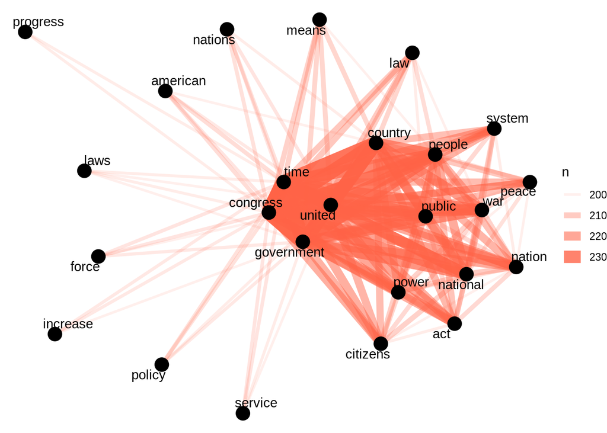

```r
library(igraph)
library(ggraph)
sotu_word_pairs %>%
  filter(n >= 200) %>%  # only word pairs that occur 200 or more times
  graph_from_data_frame() %>% #convert to graph
  ggraph(layout = "fr") + # place nodes according to the force-directed algorithm of Fruchterman and Reingold
  geom_edge_link(aes(edge_alpha = n, edge_width = n), edge_colour = "tomato") +
  geom_node_point(size = 5) +
  geom_node_text(aes(label = name), repel = TRUE,
                 point.padding = unit(0.2, "lines")) +
  theme_void()
```

(@) Create a network graph that shows the relationship between words that appear between 125 and 175 times.

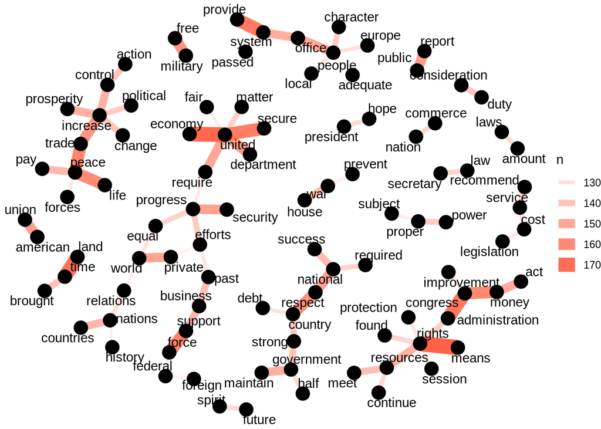

```r
sotu_word_pairs %>%
  filter(n == 125:175) %>%  # only word pairs that occur 200 or more times
  graph_from_data_frame() %>% #convert to graph
  ggraph(layout = "fr") + # place nodes according to the force-directed algorithm of Fruchterman and Reingold
  geom_edge_link(aes(edge_alpha = n, edge_width = n), edge_colour = "tomato") +
  geom_node_point(size = 5) +
  geom_node_text(aes(label = name), repel = TRUE,
                 point.padding = unit(0.2, "lines")) +
  theme_void()
```

## Analyzing Historical Journals

In the github repository below I have included the text and metadata for a journal called *Mind and Body* which ran from the 1890s until the late 1930s and chronicled the development of the physical education profession. This dataset was OCR’d from copies stored in Google Books. Using the metadata provided and the raw text files can you use what you learned above to analyze these texts? What historical conclusions might you be able to draw?

```r
#zip file of all the .txt files. One for each issue.
download.file("https://github.com/regan008/8510-TextAnalysisData/blob/main/MindAndBody.zip?raw=true", "MindAndBody.zip")
unzip("MindAndBody.zip")
# Metadata that includes info about each issue.
metadata <- read.csv("https://github.com/regan008/8510-TextAnalysisData/blob/main/mb-metadata.csv")
```

8. Add code chunks below and intersperse text to explain what you are doing and why.

```r
mind.body <- readtext(file.path("~/Desktop/8510-Worksheets/txt"))

#mind.body.whole <- metadata %>%
  #bind_cols(mind.body) %>% # combine with texts
  #as_tibble() # convert to tibble
#glimpse(mind.body.whole)
#well that did not work since the metadata is useless and it has more observations than the text data itself (?).

#pre-processing: tokenization
tidy.mind.body <- mind.body %>%
  unnest_tokens(word, text) %>%
  anti_join(stop_words_custom) #removing the stop words
glimpse(tidy.mind.body)
```

```
## Rows: 3,413,012
## Columns: 2
## $ doc_id <chr> "MB_1895_Apr.txt", "MB_1895_Apr.txt", "MB_1895_Apr.txt", "MB_18…
## $ word   <chr> "editorial", "committee", "karl", "kroh", "cook", "normal", "sc…
```

```r
tidy.mind.body %>%
  count(word, sort = TRUE) #%>% #raw count of words
```

```
## readtext object consisting of 100331 documents and 0 docvars.
## # Description: df [100,331 × 3]
##   word         n text
##   <chr>    <int> <chr>
## 1 1        31872 "\"\"..."
## 2 physical 27959 "\"\"..."
## 3 school   22551 "\"\"..."
## 4 2        20497 "\"\"..."
## 5 left     20364 "\"\"..."
## 6 4        18568 "\"\"..."
## # … with 100,325 more rows
```

```r
 # as.data.frame()

tidy.mind.body %>%
  filter(word %in% c("future", "past")) %>% #searching for the occurrance of words future and past
  count(doc_id, word, sort = TRUE) #%>%
```

```
## readtext object consisting of 752 documents and 1 docvar.
## # Description: df [752 × 4]
##   doc_id            word       n text
##   <chr>             <chr>  <int> <chr>
## 1 MB_1902_April.txt future    28 "\"\"..."
## 2 MB_1931_June.txt  past      13 "\"\"..."
## 3 MB_1934_Feb.txt   past      12 "\"\"..."
## 4 MB_1935_April.txt past      12 "\"\"..."
## 5 MB_1909_March.txt past      11 "\"\"..."
## 6 MB_1910_May.txt   future    11 "\"\"..."
## # … with 746 more rows
```

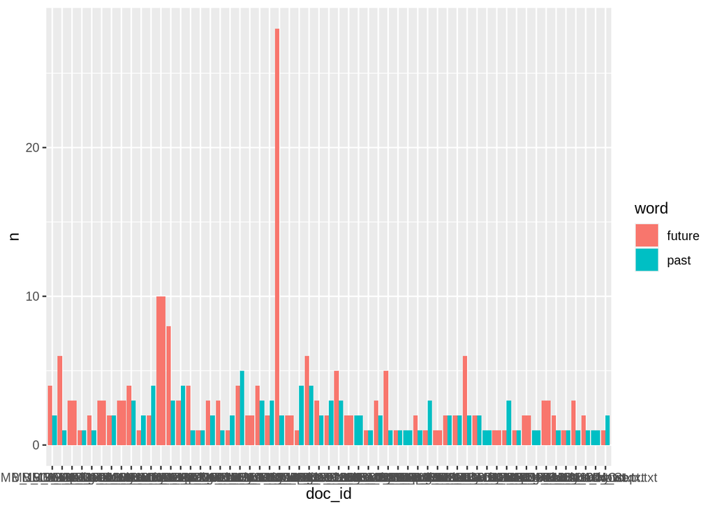

```r
  #as.data.frame()

mb.past.future <- tidy.mind.body %>%
  filter(word %in% c("future", "past")) %>%
  count(doc_id, word, sort = TRUE) %>%
  filter(grepl("1900", doc_id) | grepl("1901", doc_id) | grepl("1902", doc_id) | grepl("1903", doc_id) | grepl("1904", doc_id))

mb.past.future %>%
  ggplot(aes(doc_id, n, fill = word)) +
  geom_bar(position = "dodge", stat = "identity")
```